Skip to main content

# Job Satisfaction in Switzerland: Occupational Differences and Economic Events (2004–2024)

- Show All Code
- Hide All Code
- View Source

Authors

Affiliation

Dylan Baerfuss

HEC Lausanne, University of Lausanne

Francesco Righini

Published

November 16, 2026

Abstract

This project examines job satisfaction among employed people in Switzerland using 21 annual waves of the Swiss Household Panel (2004–2024). The employed sample contains 124,769 respondent-year observations. We investigate occupational and demographic differences, changes around the 2009 financial crisis, the 2015 Swiss franc shock and the 2020 COVID-19 pandemic, and whether occupational gaps vary across broader economic periods. Exploratory analysis and preliminary OLS regressions with respondent-clustered standard errors show that satisfaction differs across groups and years. The unweighted annual mean declined from 8.212 in 2004 to 7.815 in 2024, and occupation-by-period interactions are jointly significant. The results describe associations, not causal effects, and are subject to missingness, changing sample composition and survey-design limitations.

# 1 Introduction

## 1.1 Project Goals

Job satisfaction is an important topic in management and organisational behaviour because it helps us understand how employees experience their work. It is also relevant to decisions about employee retention, working conditions and workforce management. However, job satisfaction can differ depending on occupation, employment arrangements, career opportunities and the wider economic environment. Looking at only one company or one year would therefore give us a limited picture.

For this project, we chose to study job satisfaction across Switzerland using the **Swiss Household Panel (SHP)**. By combining annual survey data from **2004 to 2024**, we can compare different occupational and demographic groups and examine how satisfaction has changed over time. Switzerland is an interesting setting because its labour market includes a wide range of occupations and regions. It also experienced several major economic events during our study period, including the **2009 financial crisis**, the **2015 Swiss franc shock** and the **2020 COVID-19 pandemic**. We wanted to investigate whether job satisfaction changed around these events and whether some occupational groups were affected differently.

Our main objective is to identify patterns in job satisfaction and examine whether differences between groups and periods are **statistically significant**. We follow the data science workflow covered in class: preparing and cleaning the data, conducting **exploratory data analysis (EDA)**, comparing groups and applying statistical tests. This allows us to move beyond simply describing the data and examine whether the differences we observe are supported by statistical evidence. However, our results show associations and cannot establish that economic events or individual characteristics directly caused changes in satisfaction.

We also made some changes to our initial project proposal after exploring the available data. We originally considered the full period from 1999 to 2024, but the general job satisfaction variable was missing for several earlier years. We therefore restricted our analysis to **2004–2024**, giving us 21 annual survey waves with a more consistent measure. We also clarified that our regional variable refers to **region of residence**, rather than workplace location, and included employment arrangements as an additional comparison. These decisions helped us define a more practical and consistent scope for the analysis.

## 1.2 Research Questions

Our main research question is:

**How does job satisfaction in Switzerland vary across occupational groups, age, gender and region, and how does it evolve during periods of economic stress?**

To answer this, we divided our analysis into three research questions:

- **RQ1.1:** What are the differences in average job satisfaction between occupational groups, age groups, men and women, and regions? We also examine differences by employment arrangement.
- **RQ1.2:** How does job satisfaction change around major economic events (the 2009 financial crisis, the 2015 Swiss franc shock and the 2020 COVID-19 pandemic) compared with surrounding years and, where feasible, calmer periods?
- **RQ1.3:** How do differences in job satisfaction between occupational groups change across different economic periods?

We structured the questions to move from general comparisons to more detailed analysis.

First, **RQ1.1** examines differences between groups of workers. This gives us a starting point for understanding which groups report higher or lower satisfaction. Next, **RQ1.2** looks at changes around the three economic events. We compare the year before, the event year and the following year to see whether any noticeable changes occurred.

Finally, **RQ1.3** builds on the first two questions by examining whether occupational differences change across four broader economic periods: **2004–2008, 2009–2014, 2015–2019 and 2020–2024**. Rather than looking only at overall satisfaction, we want to understand whether the gaps between occupations remain similar or vary depending on the economic period.

Together, these questions guide our data preparation, visualisations and statistical analysis.

## 1.3 Related Work

Job satisfaction is often studied using employee surveys, but surveys within a single organisation may not represent the wider labour market. We chose the **Swiss Household Panel (SHP)** because it collects information on individuals and households across Switzerland over multiple years. It includes job satisfaction alongside occupational, demographic and household characteristics, allowing us to compare groups and examine changes over time (SHP Group, 2026).

The SHP is managed by **FORS** and distributed through **SWISSUbase**. We use **Version 12.0**, excluding the beta Wave 27, and focus on the 2004–2024 waves. Using the same survey source across years gives us a basis for comparing job satisfaction over time, although changes in respondents and sample composition still need to be considered.

For the technical part of the project, we use **Python** and the methods introduced in our Data Science Methods for Management module. We use **pandas** to select variables, clean missing values, harmonise annual datasets and merge individual and household information. Our approach follows the data preparation practices described by McKinney (2022) and the pandas documentation (pandas development team, n.d.).

We then use **Matplotlib** to create visualisations for our exploratory data analysis (Matplotlib development team, n.d.). These include distributions, comparisons between groups and trends over time. We chose these visualisations because they help us identify patterns, unusual values and possible relationships before moving to statistical testing.

For the statistical analysis, we use **descriptive statistics** and **ordinary least squares (OLS) regression**, implemented with statsmodels (statsmodels developers, n.d.). The regression models allow us to examine differences between groups while accounting for other observed characteristics. Since some respondents appear in multiple survey years, we use **respondent-clustered standard errors** to account for repeated observations from the same person.

These methods provide a starting point for examining relationships in the data. However, they do not fully account for the SHP’s complex survey design, changes in sample composition or unobserved differences between respondents. We therefore interpret our findings as **associations rather than causal effects**.

With the research questions and analytical approach defined, the next section explains the dataset, the variables we selected and the cleaning steps needed before conducting the exploratory analysis.

# 2 Data

## 2.1 Sources

Our main data source is the **Swiss Household Panel (SHP)**, *Living in Switzerland Waves 1–26 + Long file + Beta version Wave 27*, Version 12.0, published by **FORS** and distributed through **SWISSUbase** (SHP Group, 2026). The version-specific DOI is 10.48573/haxy-c230, while the canonical DOI is 10.48573/pjmf-8s41. We received approval to access the data for this educational project on **19 October 2026**.

We chose the SHP because it follows individuals and households across multiple years and contains information on employment, occupation, demographics and job satisfaction. This allows us to compare different groups of workers and examine how satisfaction changes over time using the same survey source.

Although the dataset covers years starting from 1999, we restricted our analysis to **2004–2024**, giving us **21 annual waves**. During our initial exploration, we found that the general job satisfaction variable was unavailable in several earlier years, particularly 2000–2003. Including these years would have created gaps in our analysis, so we decided to focus on the period with more consistent coverage. We also excluded the beta Wave 27 because it was not part of the finalised waves used in our study.

We used the annual **SAS files** to combine individual and household information. As the SHP microdata are access-controlled, the original files are stored locally and are not uploaded to our GitHub repository or distributed with the report.

## 2.2 Description

After preparing the annual survey files, we created three datasets for different stages of the analysis.

| Dataset | Respondent-year observations | Unique respondents | Purpose |
| --- | --- | --- | --- |
| Full dataset | 305,462 | 45,632 | Combined individual and household records |
| Employed sample | 124,769 | 22,265 | Employed respondents with valid occupation and job satisfaction |
| Analysis sample | 124,766 | — | Employed sample excluding missing age or sex |

The **full dataset** contains all harmonised observations from 2004 to 2024. We then created the **employed sample** because our research focuses on job satisfaction among people who are working. Finally, we created the **analysis sample** by removing observations with missing age or sex values, allowing us to compare demographic groups more consistently.

The full dataset contains **10 standardised variables**:

- `IDPERS`: Respondent identifier.
- `IDHOUS`: Household identifier.
- `YEAR`: Survey year.
- `AGE`: Respondent’s age.
- `SEX`: Respondent’s sex.
- `EMPLOYMENT_STATUS`: Employment arrangement.
- `WORKING_STATUS`: Whether the respondent is working.
- `OCCUPATION`: Occupational group based on ISCO major groups.
- `JOB_SATISFACTION`: General job satisfaction score.
- `REGION`: Region of residence.

Our main variable is **job satisfaction**, measured on a **0–10 scale**, where higher values indicate greater satisfaction. We use occupation to compare different types of work, while age, sex, employment arrangements and region allow us to examine whether satisfaction varies across demographic and employment groups.

We use **ISCO major groups** to classify occupations because they provide a consistent way to compare different types of jobs. We also keep the distinction between `WORKING_STATUS` and `EMPLOYMENT_STATUS`: the first identifies whether someone is working, while the second is used to compare employment arrangements.

One limitation is that `REGION` refers to the respondent’s **region of residence**, not necessarily their workplace. We therefore interpret regional differences as differences between residents of different regions rather than differences between regional labour markets.

Each row represents one respondent in one survey year, known as a **respondent-year observation**. Because some people participate in several waves, the same respondent can appear more than once. This is important for the statistical analysis because repeated observations from one person may be related.

## 2.3 Loading Data

We initially loaded the annual SHP files in **SAS format** using Python and `pyreadstat`. We selected the variables needed for our research and combined the relevant individual and household information.

Rather than processing all the original files every time we run the report, we saved the cleaned and harmonised datasets as **CSV files** in `data/processed/`. This makes the workflow more efficient and allows us to use the same prepared data throughout the report.

The preparation was carried out in `01_data_preparation.ipynb`, using **pandas** for data manipulation (McKinney, 2022; pandas development team, n.d.).

The following Python code loads the three processed datasets. It uses paths relative to the project folder so that the same code can be used on different computers, provided the processed files are available.

```python
import pandas as pd
from IPython.display import display
from pathlib import Path

project_root = Path.cwd().resolve()

if not (project_root / "data" / "processed").is_dir():
    project_root = project_root.parent

processed_dir = project_root / "data" / "processed"

full_dataset = pd.read_csv(processed_dir / "full_dataset.csv")
employed_sample = pd.read_csv(processed_dir / "employed_sample.csv")
analysis_sample = pd.read_csv(processed_dir / "analysis_sample.csv")

sample_overview = pd.DataFrame({
    "Dataset": [
        "Full dataset",
        "Employed sample",
        "Analysis sample"
    ],
    "Observations": [
        len(full_dataset),
        len(employed_sample),
        len(analysis_sample)
    ],
    "Variables": [
        full_dataset.shape[1],
        employed_sample.shape[1],
        analysis_sample.shape[1]
    ],
})

display(sample_overview)
```

|  | Dataset | Observations | Variables |
| --- | --- | --- | --- |
| 0 | Full dataset | 305462 | 10 |
| 1 | Employed sample | 124769 | 10 |
| 2 | Analysis sample | 124766 | 10 |

The loading check confirms that all three datasets contain the expected number of observations and **10 variables**. The full dataset contains **305,462 observations**, while the employed and analysis samples contain **124,769** and **124,766 observations**, respectively.

Keeping separate datasets allows us to check the original information, work with employed respondents and apply additional restrictions for statistical analysis without repeating the cleaning process.

## 2.4 Wrangling

### 2.4.1 General Transformations

Before combining the annual datasets, we needed to make sure that variables from different survey years could be compared. This is an important part of **data cleaning and harmonisation**, especially when working with survey data collected over a long period.

We started by inspecting the available variables and their coding in individual survey waves. We tested the preparation process on selected years before applying it to all **21 waves from 2004 to 2024**. This helped us identify differences in variable names, missing-value codes and file structures before combining the data.

Our preparation followed these steps:

1. **Variable selection:** We kept the individual and household variables needed to answer our research questions.
2. **Missing-value treatment:** We converted special survey codes representing missing or invalid answers into missing values.
3. **Harmonisation:** We standardised variable names and coding across years.
4. **Merging:** We combined individual and household information using the appropriate identifiers.
5. **Concatenation:** We added the survey year and combined all annual datasets into one dataset.
6. **Sample selection:** We filtered the combined dataset to retain employed respondents with valid occupation and job satisfaction values.

For the employed sample, we kept observations where `WORKING_STATUS == 1`, occupation belonged to the valid **ISCO major groups 0–9**, and job satisfaction was between **0 and 10**.

We used `WORKING_STATUS` rather than `EMPLOYMENT_STATUS` to identify working respondents because the latter is needed to compare employment arrangements. This avoids using the same variable for two different purposes.

The employed sample contains **124,769 observations**. We then excluded two observations with missing age and one with missing sex, leaving **124,766 observations** in the analysis sample. Some regression models require additional complete-case restrictions, which are explained in the Analysis section.

These transformations gave us a more consistent dataset for comparing job satisfaction across groups and years.

### 2.4.2 Spotting Mistakes and Missing Data

After combining the datasets, we checked for **missing values, duplicate records and inconsistencies**. These checks were necessary because missing or duplicated observations could affect our group comparisons and statistical results.

We first checked whether each respondent had more than one record for the same survey year. We found **no duplicate respondent-year combinations**. We also confirmed that respondent ID, survey year, household ID and region were complete in the full dataset.

However, some variables contained missing values:

| Variable | Missing observations in full dataset |
| --- | --- |
| Age | 232 |
| Sex | 4 |
| Employment status | 1,003 |
| Occupation | 180,252 |
| Job satisfaction | 178,161 |

Occupation and job satisfaction have the largest numbers of missing observations. This is partly because the full dataset includes people who are not employed, for whom these questions may not apply.

We considered how to handle these missing values. Since **occupation and job satisfaction are central to our research questions**, we decided not to estimate or replace missing responses through **imputation**. Instead, we restricted the employed sample to respondents with valid values for both variables.

This approach ensures that our comparisons use observed responses rather than estimated values. However, excluding observations can introduce **selection bias** if respondents with missing information differ systematically from those included in the sample.

We therefore use the cleaned sample for the main analysis while recognising that it may not fully represent every employed person in Switzerland.

### 2.4.3 Listing Anomalies and Outliers

We also checked for unusual values and possible errors in the dataset. This included reviewing the permitted ranges of variables, special missing-value codes and duplicate records.

For job satisfaction, the valid range is **0–10**. Although responses of 0 or 10 are at the extremes of the scale, they are still valid survey answers. We therefore kept them rather than treating them as outliers.

For occupation, we used the valid **ISCO major groups 0–9**. We noticed that the **Armed Forces group (ISCO 0)** was much smaller than the other occupational groups, with only **131 observations** in the demographic analysis sample.

Because this group is small and differs from civilian occupations, we excluded it from the civilian-occupation regressions and some comparative visualisations. However, we retained it in the broader prepared dataset rather than deleting those observations entirely.

These checks helped us avoid removing valid information while identifying groups that require more careful interpretation.

### 2.4.4 Survey Weights and Comparability

Since the SHP is a survey, we also considered whether differences in the sample across years could affect our results. The dataset provides **annual individual cross-sectional survey weights**, which can help account for differences in respondents’ representation in the survey.

We matched the weights to the employed sample using respondent ID and survey year. Of the **124,769 employed observations**, **121,547 (97.42%)** had positive weights. The remaining **3,222 observations** had zero or negative weight codes and were excluded from the weighted calculations.

To examine whether weighting affected our results, we compared the **weighted and unweighted average job satisfaction** in 2004 and 2024.

| Annual mean job satisfaction | 2004 | 2024 | Change |
| --- | --- | --- | --- |
| Unweighted | 8.212 | 7.815 | -0.397 |
| Weighted | 8.207 | 7.711 | -0.496 |

Both approaches show a decline in average job satisfaction between 2004 and 2024. The weighted comparison shows a slightly larger decrease, suggesting that sample composition and survey weights can affect the estimated trend.

For our main **exploratory data analysis**, we use unweighted results because our initial aim is to describe patterns within the observed sample. We use the weighted annual averages as a **robustness check** to see whether the overall direction changes when survey weights are applied.

However, the weights were not adjusted specifically for the employed subgroup, and our calculations do not fully account for the SHP’s **complex survey design**. We therefore avoid treating the weighted results as fully representative population estimates.

We also account for repeated observations of the same respondents in the preliminary regression analysis by using **respondent-clustered standard errors**.

The complete data preparation and validation code is available in `01_data_preparation.ipynb`. In this report, we focus on the main cleaning decisions, checks and their implications for our analysis.

With the data prepared and the main limitations identified, the next section uses **exploratory data analysis (EDA)** to examine the distribution of job satisfaction, compare groups and investigate changes over time before applying formal statistical tests.

# 3 Exploratory Data Analysis (EDA)

We use exploratory data analysis (EDA) to understand how job satisfaction is distributed, how it changed from 2004 to 2024, and how it differs across groups. We begin with individual variables, then compare two variables at a time, and finally examine occupation and economic period together. This order helps us identify which patterns are worth testing in Section 4. All figures use **unweighted respondent-year observations** from the employed sample unless otherwise stated. Because respondents can appear in several years, these plots describe the sample rather than independent individuals. Formal statistical tests are presented in the Analysis section.

## 3.1 Univariate Analysis

### 3.1.1 Distribution of job satisfaction

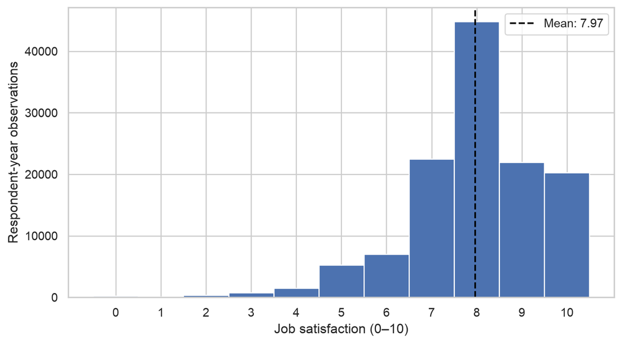

Figure 1: Distribution of reported job satisfaction among employed respondents, 2004–2024.

We use a histogram because satisfaction is recorded as whole-number scores from 0 to 10; it shows how frequently each score appears, not just the average. As shown in Figure 1, job satisfaction is concentrated toward the upper end of the 0–10 scale, with a median of **8**. The distribution is not symmetric: relatively few respondents report very low satisfaction. For this reason, we examine both the mean and the percentage reporting **low satisfaction (0–5)** rather than relying on the mean alone.

### 3.1.2 Summary statistics and potential outliers

Table 1: Descriptive statistics for job satisfaction and age in the employed analysis sample.

|  | N | Mean | SD | Median | Minimum | Maximum |
| --- | --- | --- | --- | --- | --- | --- |
| JOB_SATISFACTION | 124766.0 | 7.97 | 1.48 | 8.0 | 0.0 | 10.0 |
| AGE | 124766.0 | 44.09 | 14.45 | 46.0 | 14.0 | 97.0 |

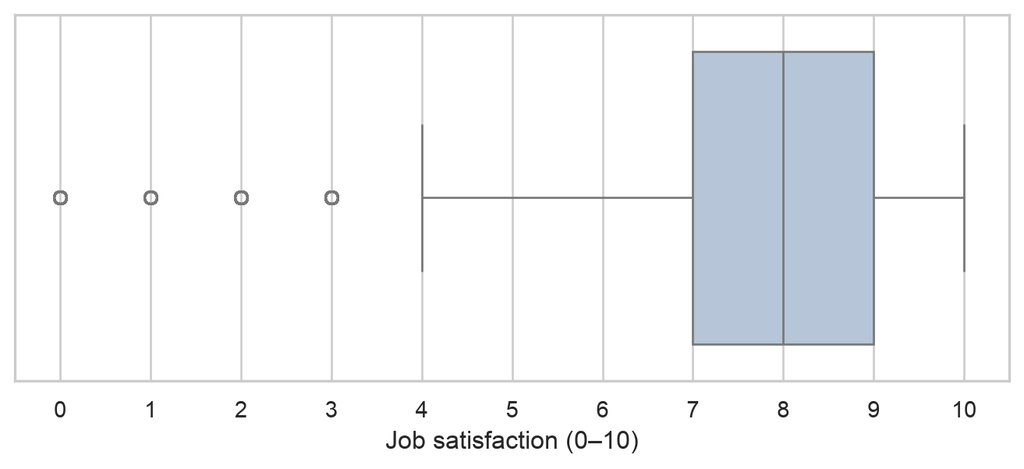

Figure 2: Box plot of job satisfaction scores (0–10); extreme responses are retained as valid survey answers.

Table 1 reports the central tendency and spread of the two continuous variables used in the project. We added a box plot to check the spread and identify potentially unusual responses. The distribution in Figure 2 is bounded by the questionnaire’s 0–10 scale and is concentrated toward high satisfaction. Values at the low end can appear as statistical outliers in a box plot, but **they are valid survey responses, not data errors**, so we do not remove them. The bounded, uneven distribution also motivates reporting medians and the low-satisfaction share alongside means. The subsequent regressions use respondent-clustered standard errors because individuals can contribute several observations.

## 3.2 Bivariate Analysis

### 3.2.1 Overall trend in job satisfaction

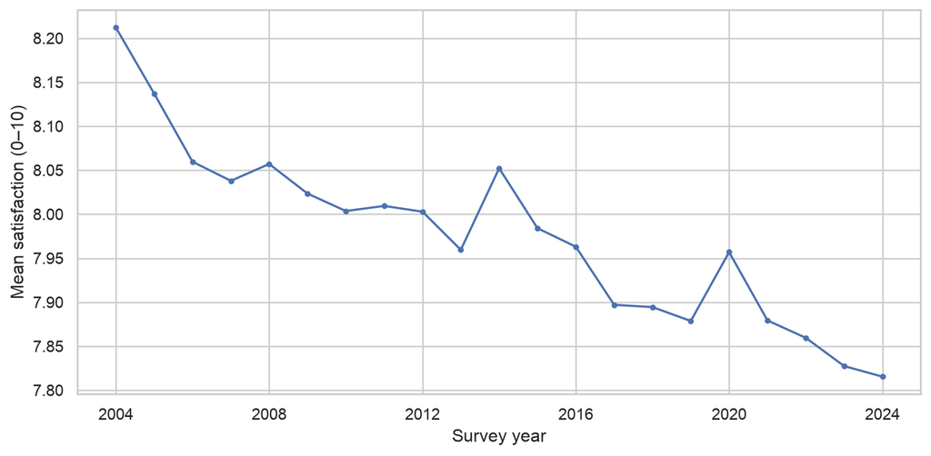

(a) Annual unweighted mean job satisfaction, 2004–2024.

|  | YEAR | mean_satisfaction | low_satisfaction |
| --- | --- | --- | --- |
| 0 | 2004 | 8.212 | 0.063 |
| 20 | 2024 | 7.815 | 0.076 |

(b)

Figure 3

As shown in Figure 3, the unweighted mean fell from **8.212 in 2004** to **7.815 in 2024**, a decline of **0.397 points**. The percentage reporting low satisfaction rose from **6.27%** to **7.56%**. We use a line chart because the order of the survey years matters. These are descriptive trends: changes in who responded each year may also influence the average. The next comparison looks at whether this overall pattern differs by occupation.

### 3.2.2 Occupational differences (RQ1.1)

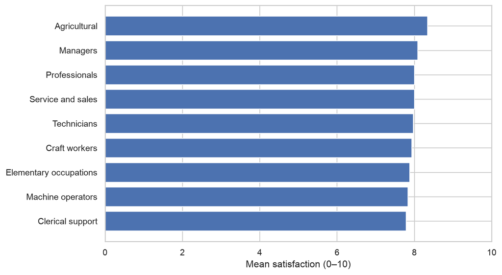

Figure 4: Mean job satisfaction by civilian occupational group, pooled across 2004–2024.

We use a horizontal bar chart to compare the nine occupation categories without suggesting that their numerical ISCO codes have a continuous scale. As shown in Figure 4, average satisfaction differs across occupational groups. Agricultural workers have the highest pooled average, while clerical support workers have the lowest among the nine civilian groups. We exclude Armed Forces (ISCO 0) from this comparison because of its small sample. Differences in occupation may overlap with age, region and employment arrangements; the Analysis section tests adjusted associations.

The pooled averages are useful for comparing occupations, but they can hide changes within each occupation over time. We therefore use a line for each occupation to compare its direction of change and a separate gap chart to summarise the spread between occupations. We additionally examine **annual occupation means** and the gap between the highest and lowest civilian occupation averages each year. We include these checks to see whether the overall decline is shared across occupations and whether occupational differences have widened or narrowed.

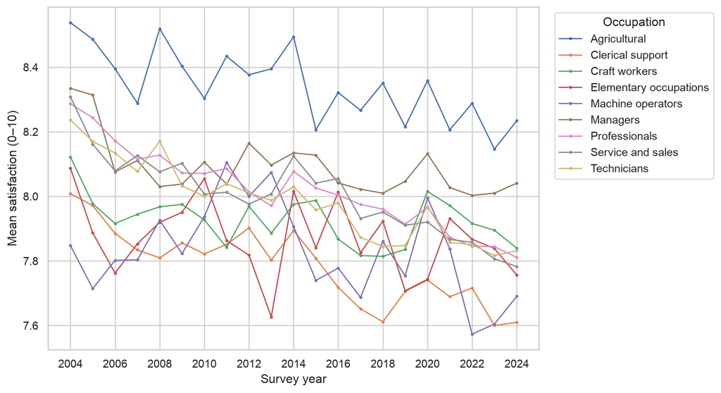

Figure 5: Annual mean job satisfaction by civilian occupation, 2004–2024.

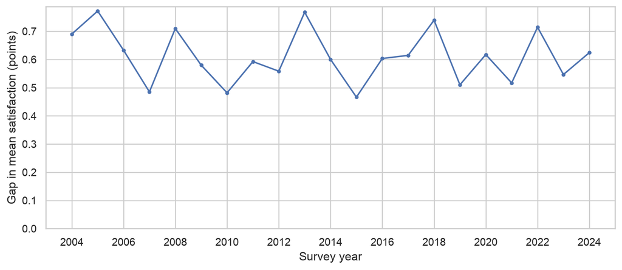

(a) Difference between the highest and lowest civilian occupational mean each year.

| YEAR | highest | lowest | gap |
| --- | --- | --- | --- |
| 2004 | 8.538 | 7.848 | 0.690 |
| 2024 | 8.234 | 7.610 | 0.624 |

(b)

Figure 6

These figures add a time dimension to RQ1.1. The gap is calculated from the highest and lowest occupation means **within each year**, so the occupations defining it can change. Small occupational samples may also produce unstable annual averages. We therefore treat these patterns as a starting point for the occupation-by-period analysis, not as proof that occupation itself caused the differences.

### 3.2.3 Demographic and employment differences (RQ1.1)

```
Age group
```

```
Sex
```

```
Employment arrangement
```

Table 2: Mean job satisfaction by age group, sex and employment arrangement.

| Age group | Observations | Mean |
| --- | --- | --- |
| Under 25 | 15697 | 7.866 |
| 25–34 | 18299 | 7.664 |
| 35–44 | 24653 | 7.861 |
| 45–54 | 32967 | 7.955 |
| 55–64 | 26224 | 8.141 |
| 65+ | 6926 | 8.779 |

| Sex | Observations | Mean |
| --- | --- | --- |
| Men | 60807 | 7.937 |
| Women | 63958 | 7.996 |

| Employment arrangement | Observations | Mean |
| --- | --- | --- |
| Family business | 697 | 8.473 |
| Full-time (37+ hours) | 59726 | 7.914 |
| Part-time (1–4 hours) | 1025 | 8.371 |
| Part-time (5–36 hours) | 43188 | 7.959 |

We use tables here because age, sex and employment arrangement have different category definitions and sample sizes; the counts help us judge how much weight to give each mean. The group summaries in Table 2 show that satisfaction generally increases in older age groups, although these are comparisons across respondents, not evidence that aging causes higher satisfaction. Women report a slightly higher pooled mean than men. Very short part-time work and family-business work show higher unadjusted averages than full-time work, but their sample sizes are much smaller. The employment-arrangement comparison includes only records with the relevant valid categories. **Region is region of residence**, not necessarily workplace location. The regional descriptive comparison is shown next, with adjusted associations reported in the Analysis section.

Pooled means can hide changes over time. We therefore use annual line charts to check whether the small difference between men and women is stable, rather than assuming the pooled average applies to every year.

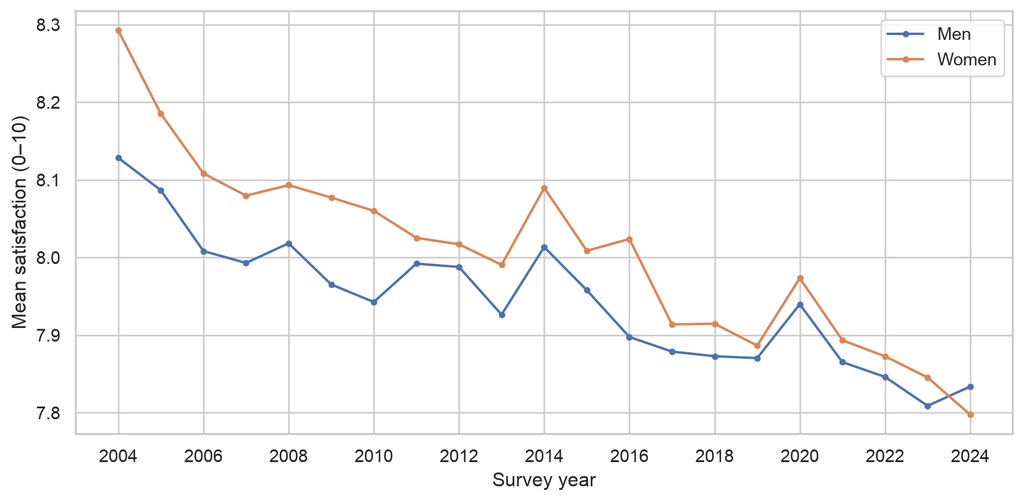

Figure 7: Annual mean job satisfaction for men and women, 2004–2024.

We apply the same approach to **age groups**. The line chart lets us compare trends while keeping age as meaningful categories, rather than treating age-group codes as continuous measurements.

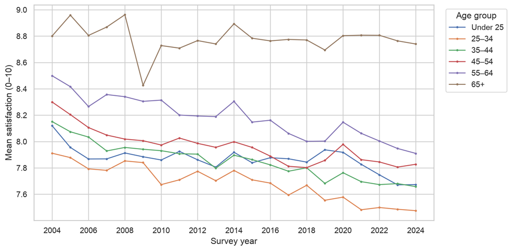

Figure 8: Annual mean job satisfaction by age group, 2004–2024.

Both charts are **unadjusted comparisons**. Differences may reflect the composition of each group as well as employment conditions. We use them to decide which demographic characteristics to include in the adjusted RQ1.1 analysis.

### 3.2.4 Regional differences (RQ1.1)

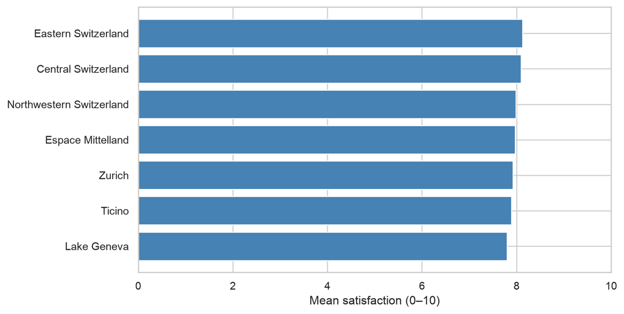

(a) Mean job satisfaction by region of residence, 2004–2024 (unweighted).

| Region | Mean | Observations |
| --- | --- | --- |
| Lake Geneva | 7.802 | 21562 |
| Ticino | 7.896 | 4186 |
| Zurich | 7.923 | 21110 |
| Espace Mittelland | 7.974 | 31605 |
| Northwestern Switzerland | 7.988 | 17397 |
| Central Switzerland | 8.099 | 13003 |
| Eastern Switzerland | 8.126 | 15906 |

(b)

Figure 9

Figure 9 compares the seven **regions of residence**, not workplace locations. The pooled averages show geographic variation in job satisfaction, which could partly reflect differences in workforce composition and employment conditions. This motivates including region as a covariate in the adjusted RQ1.1 model rather than interpreting these descriptive differences as regional effects.

We follow the pooled regional bar chart with annual line charts because a single average can hide changes across the 21 years. This lets us see whether regional differences persist or move together over time.

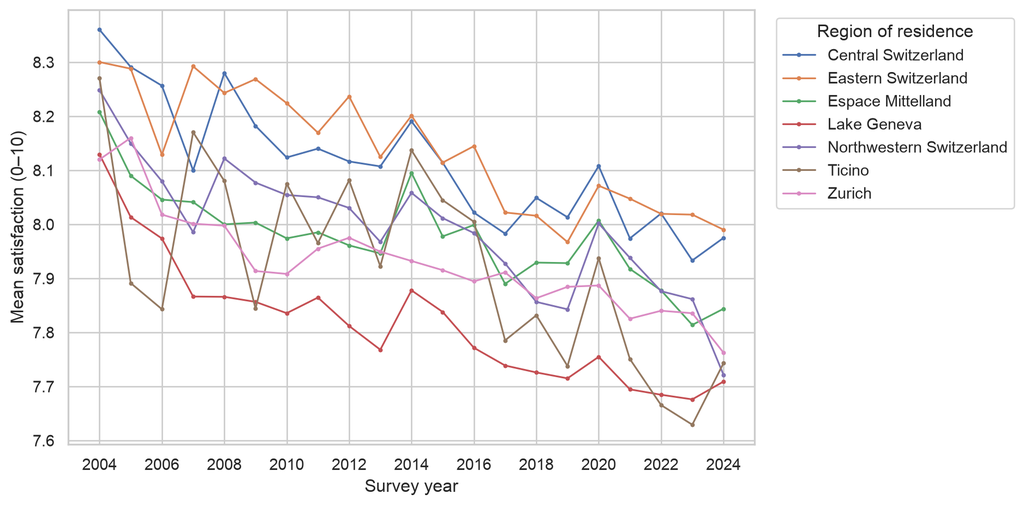

Figure 10: Annual mean job satisfaction by region of residence, 2004–2024.

This graph shows whether regional differences are relatively stable or change over time. It does not identify the reasons behind those changes, so region remains a control variable rather than a causal explanation in the later model.

### 3.2.5 Changes around economic events (RQ1.2)

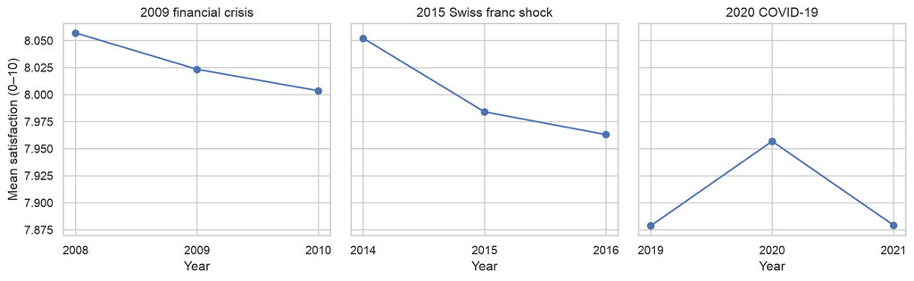

Figure 11: Mean job satisfaction in the year before, during and after three major economic events.

We use the same three-year window for each event so the before, during and after years can be compared on a consistent basis. As shown in Figure 11, the 2009 window shows a small decline; the 2015 window shows lower satisfaction during and after the franc shock; and 2020 shows a temporary increase followed by a return near the 2019 level in 2021. These windows are **not causal estimates** of the economic events. Respondent-clustered comparisons of the same years appear in the Analysis section.

Because a line chart makes the direction clearer than the exact size, we also calculate the **before-to-during**, **during-to-after**, and **before-to-after** differences using the unrounded annual means.

Table 3: Mean job satisfaction and changes across each three-year event window.

| Event | Before | During | After | Before to during | During to after | Before to after |
| --- | --- | --- | --- | --- | --- | --- |
| 2009 financial crisis | 8.057 | 8.023 | 8.004 | -0.034 | -0.020 | -0.053 |
| 2015 Swiss franc shock | 8.052 | 7.984 | 7.963 | -0.068 | -0.021 | -0.089 |
| 2020 COVID-19 | 7.879 | 7.957 | 7.879 | 0.078 | -0.078 | 0.001 |

We next compare **occupation-level changes around each event**. A grouped bar chart makes the size and direction of the changes easier to compare across occupations than nine overlapping lines. The overall mean could remain fairly stable even if some groups rise and others fall, so we calculate each group’s change from the preceding year to the event year.

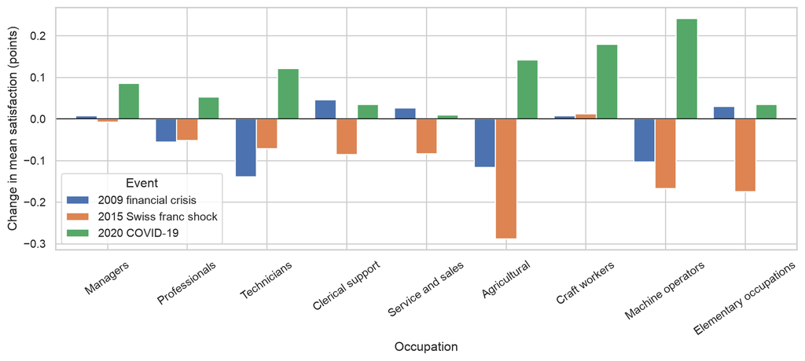

Figure 12: Change in mean satisfaction from the preceding year to each event year, by civilian occupation.

Table 4: Occupation-event comparisons with fewer than 30 observations in at least one comparison year.

```
No occupation-event comparisons have fewer than 30 observations in either comparison year.
```

The occupation-level plot is an additional **descriptive check**, not a separate causal test. We examine sample sizes because a large change based on very few respondents would be less reliable. These comparisons help motivate the broader occupation-by-period analysis in RQ1.3.

## 3.3 Multivariate Analysis

### 3.3.1 Occupation across economic periods (RQ1.3)

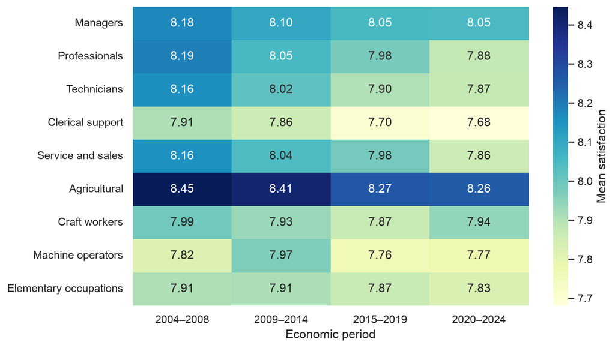

Figure 13: Average job satisfaction by occupation and broad economic period.

We use a heatmap rather than another multi-line chart because it makes comparisons across nine occupations and four periods easier to scan. The numbers inside the cells preserve the exact averages. As shown in Figure 13, occupational averages vary across the four broad periods, and the gaps between occupations are not identical in each period. These period labels are descriptive groupings, not four separate crisis treatments. The interaction regression in the Analysis section tests whether occupational differences vary significantly across periods.

## 3.4 Correlation Analysis and Choice of Visualisations

A conventional correlation matrix across the categorical variables would be misleading: `OCCUPATION`, `SEX`, `REGION`, and `EMPLOYMENT_STATUS` are numeric **codes for categories**, not continuous measurements. A correlation between their numeric codes would depend on the arbitrary numbering of categories. We therefore use group means, grouped comparisons, and the occupation-by-period heatmap instead of an inappropriate correlation heatmap or scatter plot. Relationships involving the continuous variable `AGE` are explored through age groups, which also makes the results easier to interpret for RQ1.1.

## 3.5 EDA Summary and Implications for Analysis

Taken together, the EDA results guide what we test next rather than establishing why satisfaction changed. The figures and tables above show an overall decline in satisfaction, differences between occupational and demographic groups, and changes around the three event windows. The additional **annual occupation, age, sex and regional plots** show why pooled averages alone are not enough: group differences may change over time. The **occupation-gap** and **occupation-event** comparisons help us investigate RQ1.3, while sample-size checks warn against overinterpreting small groups. The weighted annual-mean check also indicates a decline from 2004 to 2024 (**8.207 to 7.711**), although the report’s main EDA remains unweighted. These findings motivate three sets of respondent-clustered regressions: adjusted group comparisons (RQ1.1), before/during/after event-window comparisons (RQ1.2), and an occupation-by-economic-period interaction (RQ1.3). The EDA supports the selection of occupation, age, sex, region, employment arrangement and survey year for RQ1.1; short event windows for RQ1.2; and occupation-by-period interaction terms for RQ1.3. The models and significance tests are presented in the Analysis section. None of these observational comparisons establishes causation.

# 4 Preliminary Analysis

## 4.1 Methods and rationale

We use **ordinary least squares (OLS)** regression to test whether the descriptive differences in job satisfaction are statistically distinguishable from zero. The outcome is the reported **0 – 10 job-satisfaction score**. OLS gives coefficients in satisfaction points, which are straightforward to interpret. We treat occupation, age groups, sex, region of residence, employment arrangement, survey year and economic periods as categorical variables where appropriate.

One of the strong point of our data is that respondents answer the survey in several years, so their answers are not independent of each other. For this reason, we **cluster the standard errors by respondent** (`IDPERS`) in every regression, which makes the p-values more accurate.  
Clustering does not, however, account for factors that we do not observe, such as income or personality. The regressions are unweighted: we use the survey weights only to check the annual trend in the Data section, because the data are observational, the results show associations, not causal effects.

### 4.1.1 Model assumptions and checks

Like any linear regression, OLS relies on some assumptions: the model must include the relevant variables in the right form, no predictor can be an exact combination of the others, and the standard errors must reflect how the data were collected. **OLS does not require job satisfaction itself to be normally distributed**. However, the score only takes whole values from 0 to 10 and most answers are close to the top of the scale, so a linear model is only an approximation. We have not yet run formal diagnostics (for example on the residuals), so for now the coefficients should be read as preliminary differences in average satisfaction.

**Categorical variables enter the models as separate groups**, so occupation, sex and region codes are not treated as numbers. The models are not fully accountble also because of the survey is designed, more specifically the way SHP selects its households. Our goal for the final report, we will check the model diagnostics, compare the results with weighted models and look at changes within the same people over time.

Each research question has its own test: - For **RQ1.1**, we compare occupational and demographic groups while holding the other characteristics constant. - For **RQ1.2**, we compare the year before each event with the event year and the year after. - For **RQ1.3**, we check whether the gaps between occupations change across four periods. For each group of variables, we use a **joint Wald test**, which asks whether the group matters as a whole instead of looking at one category at a time.

## 4.2 RQ1.1 — Occupation, Demographics and Employment arrangements

First, we compare the **nine civilian occupational groups** and keep the survey year constant, so that differences between years do not affect the comparison. We leave out the Armed Forces components because they have very few respondents. Clerical support workers is what we choose as the **reference group**: since they have the lowest average satisfaction. Each coefficient shows how many points more satisfied another group is.

```python
rq11_data = analysis_sample[["IDPERS", "YEAR", "OCCUPATION", "JOB_SATISFACTION"]].dropna().copy()
rq11_data["OCCUPATION"] = pd.to_numeric(rq11_data["OCCUPATION"], errors="coerce")
rq11_data = rq11_data[rq11_data["OCCUPATION"].isin(range(1, 10))].copy()
rq11_data["OCCUPATION"] = rq11_data["OCCUPATION"].astype(int)
model_rq11 = smf.ols(
    "JOB_SATISFACTION ~ C(OCCUPATION, Treatment(reference=4)) + C(YEAR)",
    data=rq11_data
).fit(cov_type="cluster", cov_kwds={"groups": rq11_data["IDPERS"]})
occ_terms = [t for t in model_rq11.params.index if t.startswith("C(OCCUPATION")]
occ_test = model_rq11.wald_test(" = 0, ".join(occ_terms) + " = 0", scalar=True)
selected = {1: "Managers", 2: "Professionals", 6: "Agricultural workers"}
rows = []
for code, name in selected.items():
    term = next(t for t in occ_terms if f"[T.{code}]" in t)
    rows.append({"Occupation": name, "Difference (points)": model_rq11.params[term], "p-value": model_rq11.pvalues[term]})
table = pd.DataFrame(rows)
table["p-value"] = table["p-value"].apply(lambda p: "< 0.001" if p < 0.001 else f"{p:.3f}")
display(table.set_index("Occupation").rename_axis(None).round(3))
print(f"N = {len(rq11_data):,}; respondent-clustered Wald chi-square({len(occ_terms)}) = {float(occ_test.statistic):.2f}; {'p < 0.001' if occ_test.pvalue < 0.001 else f'p = {float(occ_test.pvalue):.3f}'}; R² = {model_rq11.rsquared:.3f}")
```

```
N = 124,635; respondent-clustered Wald chi-square(8) = 168.22; p < 0.001; R² = 0.010
```

Table 5: Selected occupation differences relative to clerical support workers, controlling for survey year.

|  | Difference (points) | p-value |
| --- | --- | --- |
| Managers | 0.317 | < 0.001 |
| Professionals | 0.231 | < 0.001 |
| Agricultural workers | 0.560 | < 0.001 |

As shown in Table 5, occupational differences are jointly significant (χ²(8) = **168.22**, p < 0.001; **124,635 observations**). Relative to clerical support workers, agricultural workers (+0.560 points), managers (+0.317) and professionals (+0.231) have higher average satisfaction after controlling for survey year. This is evidence of differences between occupational groups, since half point a a decimal scale is quite significant, but not enough to conclude that occupation itself causes satisfaction.

Next, we add age group, sex, region of residence and employment arrangement to the same model, so that each characteristic is compared while the others are kept as constant. This model uses fewer observations, because we keep only respondents with a valid employment arrangement and we choose to limit sex to men and women, since the “other” category is too small to be accountable. The reference groups selected are respondents under 25, managers, men, the Lake Geneva region and full-time employment.

```python
rq11_full = analysis_sample[["IDPERS", "YEAR", "JOB_SATISFACTION", "OCCUPATION", "AGE", "SEX", "REGION", "EMPLOYMENT_STATUS"]].copy()
rq11_full = rq11_full[
    rq11_full["OCCUPATION"].isin(range(1, 10))
    & rq11_full["EMPLOYMENT_STATUS"].isin([1, 2, 3, 5])
    & rq11_full["SEX"].isin([1, 2])
].dropna().copy()
rq11_full["AGE_GROUP"] = pd.cut(
    rq11_full["AGE"], bins=[0, 24, 34, 44, 54, 64, np.inf],
    labels=["Under 25", "25–34", "35–44", "45–54", "55–64", "65+"], include_lowest=True
)
model_rq11_full = smf.ols(
    "JOB_SATISFACTION ~ C(OCCUPATION) + C(AGE_GROUP) + C(SEX) + C(REGION) + C(EMPLOYMENT_STATUS) + C(YEAR)",
    data=rq11_full
).fit(cov_type="cluster", cov_kwds={"groups": rq11_full["IDPERS"]})
joint_rows = []
for variable, label in [("OCCUPATION", "Occupation"), ("AGE_GROUP", "Age group"), ("SEX", "Sex"), ("REGION", "Region of residence"), ("EMPLOYMENT_STATUS", "Employment arrangement")]:
    terms = [t for t in model_rq11_full.params.index if t.startswith(f"C({variable})[")]
    test = model_rq11_full.wald_test(" = 0, ".join(terms) + " = 0", scalar=True)
    joint_rows.append({"Variable": label, "df": len(terms), "Wald χ²": float(test.statistic), "p-value": float(test.pvalue)})
table = pd.DataFrame(joint_rows)
table["p-value"] = table["p-value"].apply(lambda p: "< 0.001" if p < 0.001 else f"{p:.3f}")
display(table.set_index("Variable").rename_axis(None).round(3))
print(f"N = {len(rq11_full):,}; respondents = {rq11_full['IDPERS'].nunique():,}; R² = {model_rq11_full.rsquared:.3f}")
```

```
N = 104,526; respondents = 18,363; R² = 0.039
```

Table 6: Joint Wald tests for groups of predictors in the adjusted RQ1.1 regression.

|  | df | Wald χ² | p-value |
| --- | --- | --- | --- |
| Occupation | 8 | 116.017 | < 0.001 |
| Age group | 5 | 670.260 | < 0.001 |
| Sex | 1 | 46.447 | < 0.001 |
| Region of residence | 6 | 119.886 | < 0.001 |
| Employment arrangement | 3 | 27.487 | < 0.001 |

As shown in Table 6, all five groups of predictors are **jointly significant** (each p < 0.001; 104,526 observations, 18,363 respondents, R² = 0.039). For example, Clerical support workers score 0.321 points lower than Managers,almost the same gap as in Table 5, so the **occupation difference does not disappear** when age, sex, region and employment arrangement are taken into account. Respondents aged 65+ score 1.088 points higher than those under 25. Part-time employment of 5–36 hours differs only slightly from full-time work. These comparisons do not imply that every category within a variable differs significantly. We retain numeric sex codes in model interpretation until their official labels are verified.

Part of this gap is probably a **selection effect**: people who keep working after the usual retirement age often do so because they like their job, while less satisfied workers are more likely to have already choose to be retired.

## 4.3 RQ1.2 — Changes around Economic Events

```python
events = {"2009 Financial Crisis": 2009, "2015 Swiss Franc Shock": 2015, "2020 COVID-19": 2020}
event_rows = []
for event_name, event_year in events.items():
    subset = analysis_sample.loc[
        analysis_sample["YEAR"].isin([event_year - 1, event_year, event_year + 1]),
        ["IDPERS", "YEAR", "JOB_SATISFACTION"]
    ].dropna().copy()
    subset["PERIOD"] = pd.Categorical(
        subset["YEAR"].map({event_year - 1: "Before", event_year: "During", event_year + 1: "After"}),
        categories=["Before", "During", "After"]
    )
    fitted = smf.ols("JOB_SATISFACTION ~ C(PERIOD, Treatment(reference='Before'))", data=subset).fit(
        cov_type="cluster", cov_kwds={"groups": subset["IDPERS"]}
    )
    for period in ["During", "After"]:
        term = next(t for t in fitted.params.index if f"[T.{period}]" in t)
        event_rows.append({"Event": event_name, "Comparison": f"{period} vs before", "Difference (points)": fitted.params[term], "p-value": fitted.pvalues[term], "N": len(subset)})
table = pd.DataFrame(event_rows)
table["p-value"] = table["p-value"].apply(lambda p: "< 0.001" if p < 0.001 else f"{p:.3f}")
display(table.set_index(["Event", "Comparison"]).rename_axis([None, None]).round(3))
```

Table 7: Differences in job satisfaction relative to the year before each economic event.

|  |  | Difference (points) | p-value | N |
| --- | --- | --- | --- | --- |
| 2009 Financial Crisis | During vs before | -0.034 | 0.147 | 14385 |
|  | After vs before | -0.053 | 0.026 | 14385 |
| 2015 Swiss Franc Shock | During vs before | -0.068 | < 0.001 | 21291 |
|  | After vs before | -0.089 | < 0.001 | 21291 |
| 2020 COVID-19 | During vs before | 0.078 | < 0.001 | 23809 |
|  | After vs before | 0.001 | 0.977 | 23809 |

As shown in Table 7, the **2009** event-year change is **not significant** (−0.034, p = 0.147), while **2010** is **slightly lower** than **2008** (−0.053, p = 0.026). The **2015** and **2016** comparisons are **both negative and significant** (−0.068 and −0.089, respectively; both p < 0.001). In **2020**, satisfaction is temporarily higher than in 2019 (+0.078, p < 0.001), but the 2021 difference is effectively zero (+0.001, p = 0.977). The magnitudes are small, and the 2009 after-year result warrants particular caution given multiple comparisons.

## 4.4 RQ1.3 — Occupation × Economic period

For the third one, we check whether the gaps between occupations **stay the same over time**. We divide the years into four periods (2004–2008, 2009–2014, 2015–2019 and 2020–2024) and allow the occupation differences to change from one period to the next, using an **interaction between occupation and period**. A **joint Wald test** then checks whether all these changes (24 coefficients) are zero, which would mean that the gaps are stable. Managers and 2004–2008 are the reference categories.

```python
rq13_data = analysis_sample[["IDPERS", "YEAR", "OCCUPATION", "JOB_SATISFACTION"]].dropna().copy()
rq13_data = rq13_data[rq13_data["OCCUPATION"].isin(range(1, 10))].copy()
rq13_data["OCCUPATION"] = rq13_data["OCCUPATION"].astype(int)
rq13_data["ECONOMIC_PERIOD"] = pd.cut(
    rq13_data["YEAR"], bins=[2003, 2008, 2014, 2019, 2024],
    labels=["2004–2008", "2009–2014", "2015–2019", "2020–2024"]
)
model_rq13 = smf.ols(
    "JOB_SATISFACTION ~ C(OCCUPATION) * C(ECONOMIC_PERIOD)", data=rq13_data
).fit(cov_type="cluster", cov_kwds={"groups": rq13_data["IDPERS"]})
interaction_terms = [t for t in model_rq13.params.index if ":" in t]
interaction_test = model_rq13.wald_test(" = 0, ".join(interaction_terms) + " = 0", scalar=True)
selected_interactions = {2: "Professionals", 3: "Technicians", 5: "Service and sales"}
interaction_rows = []
for code, name in selected_interactions.items():
    term = next(t for t in interaction_terms if f"[T.{code}]" in t and "[T.2020–2024]" in t)
    interaction_rows.append({"Occupation": name, "Interaction (points)": model_rq13.params[term], "p-value": model_rq13.pvalues[term]})
table = pd.DataFrame(interaction_rows)
table["p-value"] = table["p-value"].apply(lambda p: "< 0.001" if p < 0.001 else f"{p:.3f}")
display(table.set_index("Occupation").rename_axis(None).round(3))
print(f"N = {len(rq13_data):,}; respondents = {rq13_data['IDPERS'].nunique():,}; Wald chi-square({len(interaction_terms)}) = {float(interaction_test.statistic):.2f}; p = {float(interaction_test.pvalue):.4f}; R² = {model_rq13.rsquared:.3f}")
```

```
N = 124,635; respondents = 22,242; Wald chi-square(24) = 45.88; p = 0.0046; R² = 0.009
```

Table 8: Selected occupation-by-period interaction coefficients relative to managers and 2004–2008.

|  | Interaction (points) | p-value |
| --- | --- | --- |
| Professionals | -0.190 | 0.004 |
| Technicians | -0.161 | 0.022 |
| Service and sales | -0.174 | 0.023 |

The joint test in Table 8 is significant (**χ²(24) = 45.88, p = 0.0046**; 124,635 observations), so the gaps between occupations are not completely stable over time. The clearest change is in the last period: compared with 2004–2008, professionals (−0.190 points), technicians (−0.161) and service and sales workers (−0.174) lost ground relative to managers in 2020–2024. This does not necessarily mean that these groups became less satisfied, only that their distance from managers changed. One possible explanation is that the last period includes the pandemic, which hit service and sales jobs particularly hard, but we still need to check this in the final report. Since we test 24 coefficients, one or two could look significant just by chance, so the joint test is the main result and the individual coefficients should be read with caution.

# 5 Findings and Discussion

Taken together, the results in Table 6, Table 7 and Table 8 lead to **three preliminary conclusions**. First, **job satisfaction differs between groups of workers**: occupation, age, sex, region of residence and employment arrangement all matter, and the gap between occupations remains when the other characteristics are taken into account. Age shows the clearest pattern, with satisfaction lowest among workers in their late twenties and early thirties and highest among the oldest workers. However, these characteristics explain only a small part of the differences between individuals, so knowing someone’s group says little about how satisfied that person is. Second, **satisfaction declines slowly over the whole period, and the three economic events are not followed by the same reaction**. Around the 2009 financial crisis there is little change in the event year; around the 2015 franc shock satisfaction is lower in the event year and in the year after; in 2020 it is temporarily higher before returning to its previous level. Economic shocks therefore do not seem to lower job satisfaction automatically. Part of the 2020 increase may also come from the new sample of respondents that joined the SHP that year, which we will check in the final report. Third, **the gaps between occupations are not fixed over time**: in the most recent period, several occupational groups lost ground relative to managers, possibly in connection with the COVID-19 pandemic.

For management, these findings suggest that employee satisfaction is not uniform across worker groups or over time. Younger workers and some occupational groups appear less satisfied, which matters for retention, since dissatisfied employees are more likely to leave. At the same time, the differences are modest and based on observational data, so they should guide where an organisation looks rather than be read as evidence of what causes satisfaction, and national averages cannot replace an organisation’s own employee surveys. The results are still preliminary: the regressions are unweighted, the sample changes over time and many tests were run, as discussed in the Conclusion. For the final report, we will check the robustness of these results with weighted models and by comparing the same respondents before and after each event and, following the feedback on our proposal, focus on one economic event and on the most interesting occupational groups.

# 6 Conclusion

## 6.1 Summary

This project looks at how job satisfaction in Switzerland differs between groups of workers, how it changes around major economic events, and whether the differences between occupations stay the same over time. We use 21 waves of the Swiss Household Panel (2004–2024). After combining and cleaning the annual files, we obtain 305,462 observations from 45,632 people. Since the job-satisfaction question is only asked to people in work, our employed sample contains **124,769 observations from 22,265 individuals**. We first described the data one dimension at a time, then estimated linear regressions (OLS) with standard errors clustered by respondent, because the same people answer the survey in several years. The regressions are unweighted; the survey weights are only used to check the overall trend.

Five findings stand out. **First**, average job satisfaction fell slowly, from 8.212 in 2004 to 7.815 in 2024 on the 0–10 scale, and the decline is slightly larger when the survey weights are used (8.207 to 7.711). **Second**, satisfaction differs between occupations: agricultural workers, managers and professionals are more satisfied than clerical support workers, with gaps between about a quarter and just over half a point. **Third**, age, sex, region of residence and employment arrangement also matter, with age showing the largest differences, but together these characteristics explain only about 4% of the differences between individuals. **Fourth**, the economic events are not followed by the same reaction: satisfaction hardly changes in the 2009 crisis year, is slightly lower around the 2015 franc shock and is temporarily higher in 2020, although part of this increase may come from the new SHP sample that joined that year. **Fifth**, the gaps between occupations change over time (χ²(24) = 45.88, p = 0.0046), with several groups losing ground relative to managers in 2020–2024. These results answer our research questions at a first, descriptive level: workers’ characteristics and the period in which they are surveyed are linked to job satisfaction, but our models do not show why. For organisations, the main message is that satisfaction differs between groups, especially by age and occupation, but group averages cannot replace listening to their own employees.

## 6.2 Limitations

The first limitations concern the **data**. We start in 2004 because the general job-satisfaction question was not asked between 2000 and 2003. We also lose observations along the way: the employed sample only includes people with a valid occupation and satisfaction score, and the adjusted regression keeps 104,526 observations from 18,363 respondents, because every variable in the model must be observed. If the people we drop differ from those we keep, for example if less satisfied workers are more likely to skip questions, our averages could be slightly too high. The people in the panel also change over time, as some leave the survey and new samples join, for example in 2013 and 2020. A change in the yearly average therefore does not always mean that the same people became more or less satisfied. Finally, the region variable describes where people live, not where they work.

There are also limitations in how we **measure and model** satisfaction. Job satisfaction is a personal judgement on a 0–10 scale, and most answers are at the top of the scale, so a linear model is a simplification and very satisfied workers have little room to report further increases (a ceiling effect). Clustering the standard errors takes into account that the same people answer several times, but it does not control for characteristics we do not observe, such as income, personality or working conditions. The regressions also do not use the survey weights or the full design of the SHP: almost all observations have a valid weight, but so far we have used the weights only to check the overall trend. We have not yet run full model diagnostics. The event windows compare survey years, so they cannot show that the 2009 crisis, the 2015 franc shock or COVID-19 caused the changes. Finally, because we test many groups and interactions, a few results could be significant just by chance. Our conclusions therefore apply to the SHP respondents we analysed and should not be generalised to all Swiss workers or to other countries without further checks.

## 6.3 Future Work

Before the final report, we plan the following steps:

1. **Focus on one economic event.** Following the feedback on our proposal, we will choose one of the three events and study it in more detail. We will compare the same respondents before and after the event and, if the SHP industry variables allow it, workers who were more and less exposed to it, such as export-oriented jobs during the 2015 franc shock. This would help separate the effect of the event from the general downward trend.
2. **Look more closely at selected groups.** We will use the EDA and the occupation × period results to select the groups with the most interesting patterns, such as clerical support workers, workers aged 25–34 and the occupations that lost ground relative to managers in 2020–2024, and follow their satisfaction over time.
3. **Follow the same people over time.** Because new samples join the SHP, for example in 2013 and 2020, we will compare changes within the same individuals, for example with a respondent fixed-effects model, so that the results are not driven by who enters or leaves the panel.
4. **Use the survey weights in the models.** We will repeat the main regressions with the SHP cross-sectional weights and check whether the size and direction of the differences stay similar to the unweighted results.
5. **Check the models and the data definitions.** We will look at the residuals and try alternative age groups and event windows (for example, two years before and after each event). Because satisfaction only takes whole values from 0 to 10, we will compare the results with an ordinal model. We will also check that the employment-arrangement categories are coded the same way in every wave.

These steps build on what we have already done. The aim is not to add many new analyses, but to make the existing results more reliable and to answer the research questions in more depth: starting from the broad picture and then narrowing down, as suggested in the feedback on our proposal.

# References

Matplotlib development team. (n.d.). *Matplotlib documentation*. Retrieved November 10, 2026, from https://matplotlib.org/stable/

McKinney, W. (2022). *Python for data analysis* (3rd ed.). O’Reilly Media. https://wesmckinney.com/book/

pandas development team. (n.d.). *Pandas documentation*. Retrieved November 10, 2026, from https://pandas.pydata.org/docs/

SHP Group. (2026). *Living in switzerland waves 1-26 + long file + beta version wave 27* (Version 12.0) [Data set]. FORS. https://doi.org/10.48573/haxy-c230

statsmodels developers. (n.d.). *Statsmodels documentation*. Retrieved November 10, 2026, from https://www.statsmodels.org/stable/